# Portfolio 1 Project Description

Reilly Orman

3/22/2022

### **Dataset Description**

The data that I am going to be working with is pulled from a study called [**“Effects of Sexualized Video Games on Online Sexual Harassment”**](https://pubmed.ncbi.nlm.nih.gov/30614006/) by Jonathan Burnay and others in 2019.

I obtained this dataset from the *Harvard Dataverse*. [Here is a link to the site where I located this dataset.](https://dataverse.harvard.edu/dataset.xhtml?persistentId=doi:10.7910/DVN/9TFDEV&version=1.0)

The premise of this study was to see if sexualization of female video game characters impacts one’s sexual harassment behaviors online. Participants played a video game where the characters were either sexualized or non-sexualized. After the game, the participant had the opportunity to sexually harass a male or female partner by sending them sexist jokes.

### **Variables**

In this study, the main manipulated variable was *sexualization of the female video game characters*. This was manipulated by changing the outfit of the characters.

In the **non-sexualized condition (NS)**, both characters wore non-revealing outfits. In the **highly-sexualized condition (S)**, both characters wore revealing swimsuits.

The main dependent variable was the measure of *online sexual harassment*. After playing the video game, participants were exposed to a series of both sexist and non-sexist jokes to send to an online partner that was either male or female.

The **number of sexist jokes that the participant chose to send to their partner was measured**. There were **8** total sexist jokes that could be sent by the participant, thus, the measure of the dependent variable could range from **0 to 8.**

After playing the video game, participants rated the level of difficulty, fun, frustration, excitement, competitive, realistic, and violent the game was. Their responses were rated on a scale of **1-10, 1 = not at all, and 10 = very much.**

Other variables that might be related to online sexual harassment were measured and controlled for using measures of **Hostile Sexism (HS), Benevolent Sexism (BS), Trait Aggression (GA), and Online Disinhibition (ODS)**. HS and BS were rated on a scale of 0-5, with 0 = totally disagree and 5 = totally agree. GA and ODS were rated on a scale of 1-6, with 1 = not at all like me, and 6 = extremely like me.

| Variable | Type | Measure |
| --- | --- | --- |
| Sexualization | Character | NS, S |
| Sexual Harassment | Integer | 0-8 |

### **Set Up**

First, I am going to load the required packages and the data set.

```r
#load packages
library(tidyverse)
```

```r
library(ggplot2)
library(wesanderson)
#load data set
load(file = here::here("data", "Results_Sexual_Harassment.RData"))

#change data set name
raw_sex_harassment <- table
```

Next, I am going to change some of the variable names to more useful ones to make the data set easier to read and digest. Here, I take out some variables that are not useful to what we’re going to be looking at.

```r
#subset and wrangle the data
subset_sex_harassment <- raw_sex_harassment |>
  select(-USFIVPlayer, -Suspicious, -Player) |>
  rename(
    participant = Code,
    sexualization = Sexualization,
    partner_gender = partnergender,
    participant_gender = Participantgender,
    age = Age,
    hour_per_week = Hourweek,
    sexist_jokes = Sesistjokes,
    difficulty_rating = VGDifficulty,
    fun_rating = VGFun,
    frustration_rating = VGFrustration,
    excite_rating = VGExcitement,
    competitive_rating = VGcompetitive,
    realistic_rating = VGreaslit,
    violent_rating = VGviolent,
    hs = HS,
    bs = BS,
    ga = GA,
    ods = ODS
  ) |>
  na.omit(raw_sex_harassment)
```

Here is a glimpse of what the raw data set looks like.

```r
print(subset_sex_harassment)
```

```
## # A tibble: 211 x 18
##    participant sexualization partner_gender participant_gen~   age hour_per_week
##          <dbl> <chr>         <chr>          <chr>            <dbl>         <dbl>
##  1           1 NS            M              F                   24             0
##  2           2 S             F              M                   24             4
##  3           3 S             F              F                   22             0
##  4           4 S             F              F                   22             0
##  5           5 NS            F              F                   23             0
##  6           6 S             M              F                   21             0
##  7           7 NS            F              M                   21             6
##  8           8 S             M              F                   19             0
##  9           9 NS            M              F                   22             2
## 10          10 NS            F              F                   23             0
## # ... with 201 more rows, and 12 more variables: sexist_jokes <dbl>,
## #   difficulty_rating <dbl>, fun_rating <dbl>, frustration_rating <dbl>,
## #   excite_rating <dbl>, competitive_rating <dbl>, realistic_rating <dbl>,
## #   violent_rating <dbl>, hs <dbl>, bs <dbl>, ga <dbl>, ods <dbl>
```

### **Illustrations**

First, I am going to show the average number of sexist jokes that participants sent by gender and sexualization.

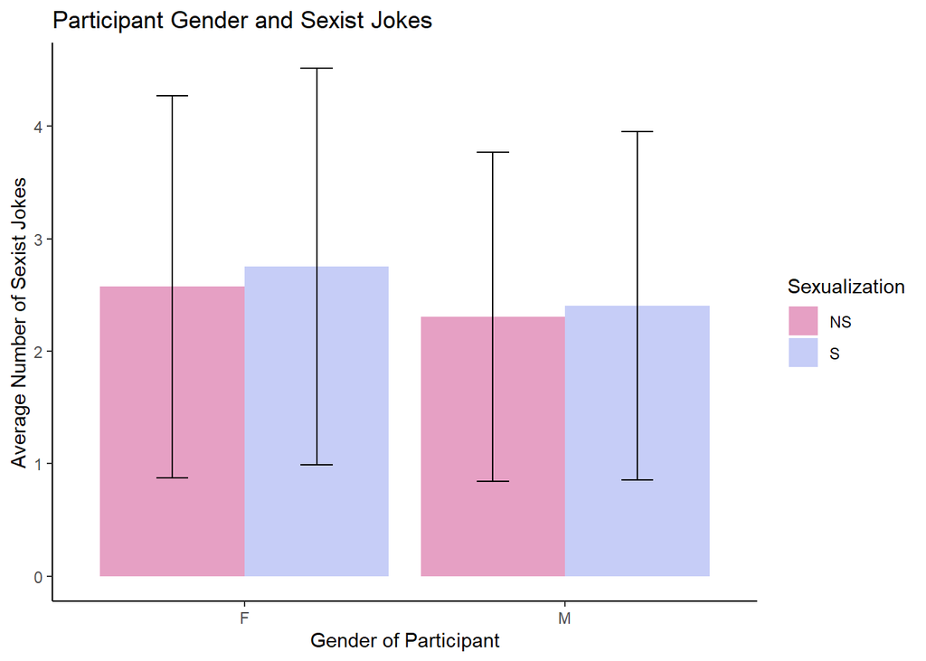

```r
#bar chart showing sexist jokes and participant gender
subset_sex_harassment |>
  group_by(participant_gender, sexualization) |>
  summarize(mean = mean(sexist_jokes),
            sd = sd(sexist_jokes)) |>
  ggplot(aes(x = participant_gender, y = mean, group = sexualization, fill = sexualization)) +
  geom_bar(stat = "identity", position = "dodge") +
  geom_errorbar(aes(ymin = mean - sd, ymax = mean + sd), width = .2, position = position_dodge(.9)) +
  scale_fill_manual(values = wes_palette("GrandBudapest2")) +
  labs(fill = "Sexualization", x = "Gender of Participant", y = "Average Number of Sexist Jokes",
       title = "Participant Gender and Sexist Jokes") +
  theme_classic()
```

On average, female participants sent a slightly higher number of sexist jokes compared to male participants. For both genders, there was a slight impact made from condition, where sexualization of video game content was slightly positively correlated with number of sexist jokes sent.

Next, I am going to visually display the interaction between the gender of the participant’s partner and the number of sexist jokes sent by condition.

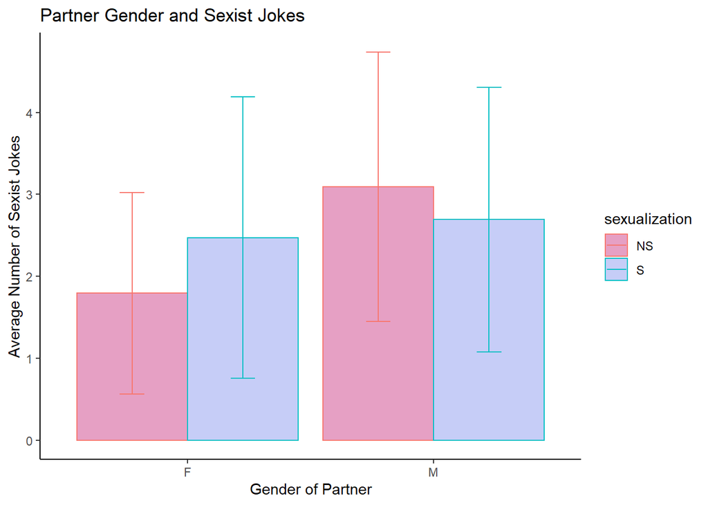

```r
subset_sex_harassment |>
  group_by(partner_gender, sexualization) |>
  summarize(mean = mean(sexist_jokes),
            sd = sd(sexist_jokes)) |>
  ggplot(aes(x = partner_gender, y = mean, group = sexualization, color = sexualization, fill = sexualization)) +
  geom_bar(stat = "identity", position = "dodge") +
  geom_errorbar(aes(ymin = mean - sd, ymax = mean + sd), width = .2, position = position_dodge(.9)) +
  scale_fill_manual(values = wes_palette("GrandBudapest2")) +
  labs(x = "Gender of Partner", y = "Average Number of Sexist Jokes",
       title = "Partner Gender and Sexist Jokes") +
  theme_classic()
```

What would our data look like if we wanted to specifically see the average number of sexist jokes that male participants sent to their female partners across conditions?

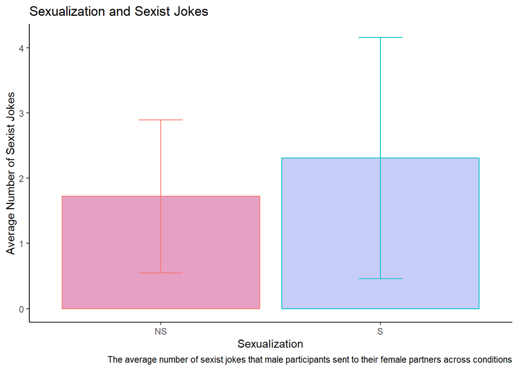

```r
#subset data to male participants with female partners
male_sex_harassment <- subset_sex_harassment |>
  filter(partner_gender == "F",
         participant_gender == "M")

#making summary table for subset data
summary_sex_harassment <- male_sex_harassment |>
  group_by(sexualization) |>
  summarize(mean = mean(sexist_jokes),
            sd = sd(sexist_jokes))

#display illustration of subset data
ggplot(summary_sex_harassment, aes(x = sexualization, y = mean, color = sexualization, fill = sexualization)) +
  geom_bar(stat = "identity", position = "dodge") +
  geom_errorbar(aes(ymin = mean - sd, ymax = mean + sd), width = .2, position = position_dodge(.9)) +
  scale_fill_manual(values = wes_palette("GrandBudapest2")) +
  labs(fill = "Sexualization", x = "Sexualization", y = "Average Number of Sexist Jokes",
       title = "Sexualization and Sexist Jokes",
       caption = "The average number of sexist jokes that male participants sent to their female partners across conditions") +
  theme_classic() +
  theme(legend.position = "none")
```

As we can see, there is a small difference in the number of sexist jokes sent by male participants to their female partners across condition. There were slightly more sexist jokes sent in the sexualized condition compared to the non-sexualized condition.

In this study, there were measures of Hostile Sexism (HS), Benevolent Sexism (BS), Trait Aggression (GA), and Online Disinhibition (ODS). How do these variables compare to the number of sexist jokes that participants sent to their partners?

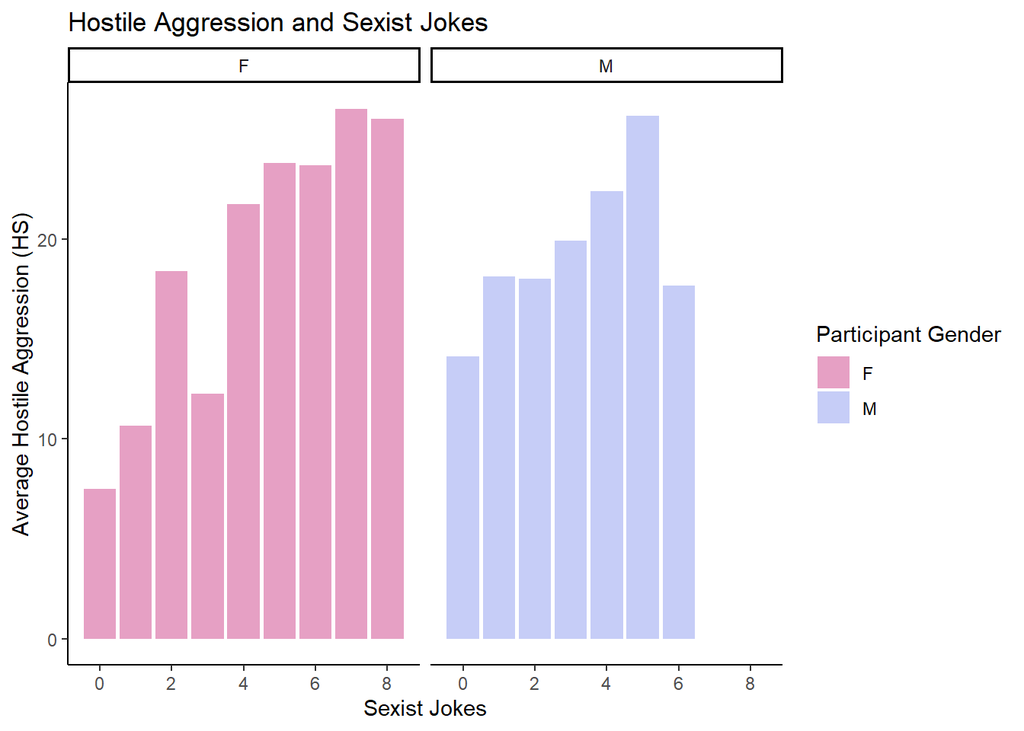

```r
#hostile sexism bar chart
subset_sex_harassment |>
  group_by(sexist_jokes, participant_gender) |>
  summarize(mean = mean(hs),
            sd = sd(hs)) |>
  ggplot() +
  aes(x = sexist_jokes,
      y = mean,
      fill = participant_gender) +
  geom_bar(stat = "identity", position = "dodge") +
  facet_grid(. ~ participant_gender) +
  scale_fill_manual(values = wes_palette("GrandBudapest2")) +
  labs(fill = "Participant Gender", x = "Sexist Jokes", y = "Average Hostile Aggression (HS)",
       title = "Hostile Aggression and Sexist Jokes") +
  theme_classic()
```

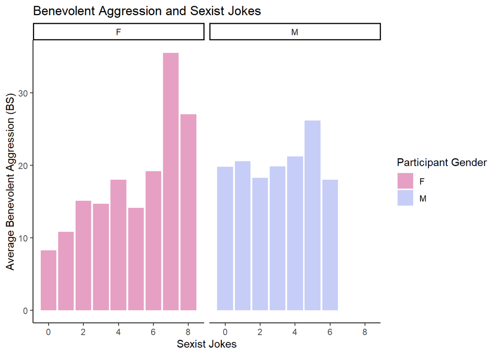

```r
#benevolent sexism bar chart
subset_sex_harassment |>
  group_by(sexist_jokes, participant_gender) |>
  summarize(mean = mean(bs),
            sd = sd(bs)) |>
  ggplot() +
  aes(x = sexist_jokes,
      y = mean,
      fill = participant_gender) +
  geom_bar(stat = "identity", position = "dodge") +
  facet_grid(. ~ participant_gender) +
  scale_fill_manual(values = wes_palette("GrandBudapest2")) +
  labs(fill = "Participant Gender", x = "Sexist Jokes", y = "Average Benevolent Aggression (BS)",
       title = "Benevolent Aggression and Sexist Jokes") +
  theme_classic()
```

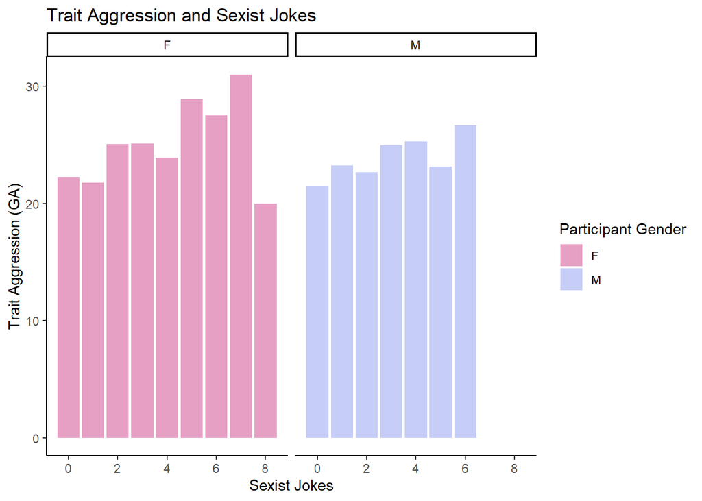

```r
#trait aggression bar chart
subset_sex_harassment |>
  group_by(sexist_jokes, participant_gender) |>
  summarize(mean = mean(ga),
            sd = sd(ga)) |>
  ggplot() +
  aes(x = sexist_jokes,
      y = mean,
      fill = participant_gender) +
  geom_bar(stat = "identity", position = "dodge") +
  facet_grid(. ~ participant_gender) +
  scale_fill_manual(values = wes_palette("GrandBudapest2")) +
  labs(fill = "Participant Gender", x = "Sexist Jokes", y = "Trait Aggression (GA)",
       title = "Trait Aggression and Sexist Jokes") +
  theme_classic()
```

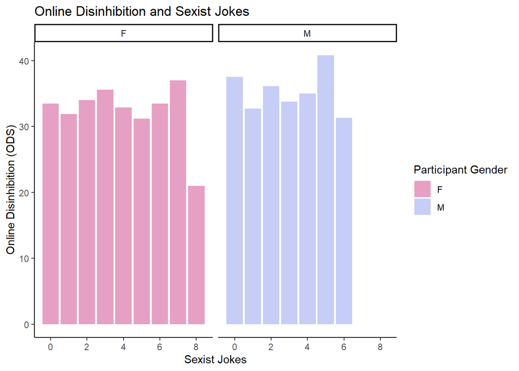

```r
#online disinhibition bar chart
subset_sex_harassment |>
  group_by(sexist_jokes, participant_gender) |>
  summarize(mean = mean(ods),
            sd = sd(ods)) |>
  ggplot() +
  aes(x = sexist_jokes,
      y = mean,
      fill = participant_gender) +
  geom_bar(stat = "identity", position = "dodge") +
  facet_grid(. ~ participant_gender) +
  scale_fill_manual(values = wes_palette("GrandBudapest2")) +
  labs(fill = "Participant Gender", x = "Sexist Jokes", y = "Online Disinhibition (ODS)",
       title = "Online Disinhibition and Sexist Jokes") +
  theme_classic()
```

It seems that **hostile aggression** and sexist jokes are positively correlated with one another among the gender of participant. In the **benevolent aggression** chart, there appears to be more of a positive correlation between benevolent aggression and number of sexist jokes sent among female participants, while there does not appear to be a significant relationship with male participants. This pattern is also prevalent among **trait aggression**, with female participants showing a stronger relationship between the two variables than male participants. **Online disinhibition** did not show any significant relationship with number of sexist jokes sent.